# HW_4P1

## ROSHAN POUDEL - HW_4_PART_1

#### An end-to-end example: A linear classifier in pure TensorFlow

**Generating two classes of random points in a 2D plane**

```python
import tensorflow as tf
import numpy as np
```

```python
num_samples_per_class = 1000
negative_samples = np.random.multivariate_normal(
    mean=[0, 3],
    cov=[[1, 0.5],[0.5, 1]],
    size=num_samples_per_class)
positive_samples = np.random.multivariate_normal(
    mean=[3, 0],
    cov=[[1, 0.5],[0.5, 1]],
    size=num_samples_per_class)
```

**Stacking the two classes into an array with shape (2000, 2)**

```python
inputs = np.vstack((negative_samples, positive_samples)).astype(np.float32)
```

**Generating the corresponding targets (0 and 1)**

```python
targets = np.vstack((np.zeros((num_samples_per_class, 1), dtype="float32"),
                     np.ones((num_samples_per_class, 1), dtype="float32")))
```

**Plotting the two point classes**

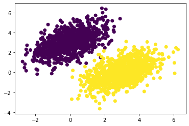

```python
import matplotlib.pyplot as plt
plt.scatter(inputs[:, 0], inputs[:, 1], c=targets[:, 0])
plt.show()
```

**Creating the linear classifier variables**

```python
input_dim = 2
output_dim = 1
W = tf.Variable(initial_value=tf.random.uniform(shape=(input_dim, output_dim)))
b = tf.Variable(initial_value=tf.zeros(shape=(output_dim,)))
```

**The forward pass function**

```python
def model(inputs):
    return tf.matmul(inputs, W) + b
```

**The mean squared error loss function**

```python
def square_loss(targets, predictions):
    per_sample_losses = tf.square(targets - predictions)
    return tf.reduce_mean(per_sample_losses)
```

**The training step function**

```python
learning_rate = 0.1

def training_step(inputs, targets):
    with tf.GradientTape() as tape:
        predictions = model(inputs)
        loss = square_loss(targets, predictions)
    grad_loss_wrt_W, grad_loss_wrt_b = tape.gradient(loss, [W, b])
    W.assign_sub(grad_loss_wrt_W * learning_rate)
    b.assign_sub(grad_loss_wrt_b * learning_rate)
    return loss
```

**The batch training loop**

```python
for step in range(40):
    loss = training_step(inputs, targets)
    print(f"Loss at step {step}: {loss:.4f}")
```

```
Loss at step 0: 4.4083
Loss at step 1: 0.7499
Loss at step 2: 0.2311
Loss at step 3: 0.1489
Loss at step 4: 0.1290
Loss at step 5: 0.1186
Loss at step 6: 0.1103
Loss at step 7: 0.1028
Loss at step 8: 0.0959
Loss at step 9: 0.0897
Loss at step 10: 0.0840
Loss at step 11: 0.0788
Loss at step 12: 0.0741
Loss at step 13: 0.0698
Loss at step 14: 0.0658
Loss at step 15: 0.0622
Loss at step 16: 0.0589
Loss at step 17: 0.0559
Loss at step 18: 0.0532
Loss at step 19: 0.0507
Loss at step 20: 0.0484
Loss at step 21: 0.0463
Loss at step 22: 0.0444
Loss at step 23: 0.0427
Loss at step 24: 0.0411
Loss at step 25: 0.0397
Loss at step 26: 0.0383
Loss at step 27: 0.0371
Loss at step 28: 0.0360
Loss at step 29: 0.0350
Loss at step 30: 0.0341
Loss at step 31: 0.0333
Loss at step 32: 0.0325
Loss at step 33: 0.0318
Loss at step 34: 0.0312
Loss at step 35: 0.0306
Loss at step 36: 0.0301
Loss at step 37: 0.0296
Loss at step 38: 0.0292
Loss at step 39: 0.0287
```

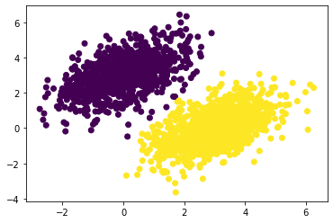

```python
predictions = model(inputs)
plt.scatter(inputs[:, 0], inputs[:, 1], c=predictions[:, 0] > 0.5)
plt.show()
```

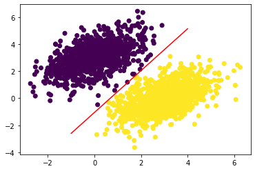

```python
x = np.linspace(-1, 4, 100)
y = - W[0] /  W[1] * x + (0.5 - b) / W[1]
plt.plot(x, y, "-r")
plt.scatter(inputs[:, 0], inputs[:, 1], c=predictions[:, 0] > 0.5)
```

> **tf.ones** --> tf.ones is a function in TensorFlow that is used to create a tensor of a given shape and fill it with ones. It is similar to the np.ones function in NumPy.

> *Syntax*: tf.ones( shape, dtype=tf.float32, name=None )

> where,

> shape: A list or tuple representing the shape of the output tensor.

> dtype: (Optional) The data type of the output tensor (default is tf.float32).

> name: (Optional) name for the operation.

> **tf.matmul** --> Calculates the matrix multiplication of given two matrices/tensors. The inner dimensions of the matrices should match.

> **tf.Variable** --> tf.Variable is a class that represents a mutable tensor. It is used to store and update values during the training process. Unlike constant tensors, tf.Variable can be updated via its assign method. To create a variable, we need to provide some initial value such as a random tensor. Example: v = tf.Variable(initial_value=tf.random.normal(shape=(3,1)))

> **tf.GradientTape()** --> tf.GradientTape is a TensorFlow API for automatic differentiation. It is used to compute gradients of a computation with respect to its input variables.

> **Activation Function** --> An activation function is a mathematical function that is applied to the output of each neuron in a neural network. The activation function takes the weighted sum of the inputs to the neuron, which includes the bias term, and applies a non-linear function to it. This new output is then passed on as input to the next layer of neurons in the neural network. By using an activation function, the neural network becomes capable of learning and modeling non-linear relationships between the inputs and outputs.

> **Loss Function**: Loss function is a mathematical function that measures the difference between the predicted output of a model and the actual target output of the training data. The loss function determines how well the model is performing on the training data. The goal of training a machine learning model is to minimize this difference (aka loss) by adjusting the parameters of the model.